# Hmk4

- Show All Code
- Hide All Code
- View Source

Author

Ziyi Tao

Github : https://github.com/t-aozy/Hmk4_STAT506.git

## Problem 1 Tidyverse

## a. Mean and median departure delay per airport.

For the departure delay, we join “faa” variable in table airports with “origin” variable in table flights.

```r
library(nycflights13)
library(dplyr)
flights <- nycflights13::flights
flights %>%
  group_by(dest)%>%
  mutate(count_dest = n())%>%
  filter(count_dest >= 10)%>%
  ungroup()%>%
  rename(faa = origin)%>%
  left_join(y = nycflights13::airports ,by = "faa")%>%
  group_by(name)%>%
  summarize(
    mean_dep_delay = mean(dep_delay, na.rm = TRUE),
    median_dep_delay = median(dep_delay, na.rm = TRUE)
  )%>%
  dplyr :: select(mean_dep_delay, median_dep_delay, name)%>%
  arrange(desc(mean_dep_delay))
```

```
# A tibble: 3 × 3
  mean_dep_delay median_dep_delay name
           <dbl>            <dbl> <chr>
1           15.1               -1 Newark Liberty Intl
2           12.1               -1 John F Kennedy Intl
3           10.3               -3 La Guardia
```

When calculating arrival delay, we join “faa” in table airports with “dest” in table flights.

```r
flights_1 <- nycflights13::flights
flights_1 %>%
  group_by(dest)%>%
  mutate(count_dest = n())%>%
  filter(count_dest >= 10)%>%
  ungroup()%>%
  rename(faa = dest)%>%
  inner_join(y = nycflights13::airports ,by = "faa")%>%
  group_by(name)%>%
  summarize(
    mean_arr_delay = mean(arr_delay, na.rm = TRUE),
    median_arr_delay = median(arr_delay, na.rm = TRUE)
  )%>%
  dplyr :: select(mean_arr_delay, median_arr_delay, name)%>%
  arrange(desc(mean_arr_delay))%>%
  print(n=98)
```

```
# A tibble: 98 × 3
   mean_arr_delay median_arr_delay name
            <dbl>            <dbl> <chr>
 1        41.8                28   "Columbia Metropolitan"
 2        33.7                14   "Tulsa Intl"
 3        30.6                16   "Will Rogers World"
 4        28.1                15   "Jackson Hole Airport"
 5        24.1                 2   "Mc Ghee Tyson"
 6        20.2                 1   "Dane Co Rgnl Truax Fld"
 7        20.1                 1   "Richmond Intl"
 8        19.7                 3   "Akron Canton Regional Airport"
 9        19.0                 0   "Des Moines Intl"
10        18.2                 1   "Gerald R Ford Intl"
11        16.9                -2   "Birmingham Intl"
12        16.2                 1   "Theodore Francis Green State"
```

[output cut: 86 more lines]

## b. How many flights did the aircraft model with the fastest average speed take?

Since the definition of average speed is not very clear, I provide 3 ways to get the result.

First, we calculate each flight’s average speed (without grouping by model) and find the flight with the fastest speed, then we record the model of that flight, then count the number of flights this model took. The model with the fastest average speed is 757-232, MPH is 703.3846, the model has taken 3980 flights. PS: we calculate MPH using distance / (air_time/60), which is included in the table flights.

```r
flight3 <- nycflights13::flights
flight3 %>%
  inner_join(nycflights13 :: planes, by = "tailnum")%>%
  mutate(
    MPH = distance /(air_time/60)
  )%>%
  group_by(model)%>%
  summarize(Number_of_Flights = n(), MPH = MPH)%>%
  arrange(desc(MPH))%>%
  head(1)
```

```
# A tibble: 1 × 3
# Groups:   model [1]
  model   Number_of_Flights   MPH
  <chr>               <int> <dbl>
1 757-232              3980  703.
```

Second, we first group by model, and calculate the average speed of all the flights with each model, find the model with the fastest average speed, and then count the flights this model took. The model with the fastest average speed is 777-222, MPH = 482.6254, has taken 4 flights.

```r
flight3 <- nycflights13::flights
flight3 %>%
  inner_join(nycflights13 :: planes, by = "tailnum")%>%
  mutate(
    MPH = distance /(air_time/60)
  )%>%
  group_by(model)%>%
  summarize(Number_of_Flights = n(),
            MPH = mean(MPH, na.rm = TRUE))%>%
  arrange(desc(MPH))%>%
  head(1)
```

```
# A tibble: 1 × 3
  model   Number_of_Flights   MPH
  <chr>               <int> <dbl>
1 777-222                 4  483.
```

Moreover, we can also directly use speed variable in table planes, where the fastest speed is 432, model is DC-9-51, which takes 91 flights.

```r
flight3 %>%
  inner_join(nycflights13 :: planes, by = "tailnum")%>%
  group_by(model)%>%
  summarize(Number_of_Flights = n(), speed = speed)%>%
  arrange(desc(speed))%>%
  head(1)
```

```
# A tibble: 1 × 3
# Groups:   model [1]
  model   Number_of_Flights speed
  <chr>               <int> <int>
1 DC-9-51                91   432
```

## Problem 2 get_temp()

## a. Form function

```r
library(stringr)
get_temp <- function(month_, year_, data,
                     celsius = FALSE, average_fn = function(x){mean(x)}){

    months <- c("January", "Feburary","March", "April", "May",
                          "June", "July", "August", "September", "October",
                          "November", "December")

    # stop when input is not included in 12 months
    # case-insensitive when matching characters
    if((month_  <= 12 & month_  >= 1 )== FALSE &
       any(grepl(tolower(month_ ), tolower(months))) == FALSE){
      stop("Input month is invalid.")
    }

    # stop when input year is not numeric
    if(is.numeric(year_)!=TRUE){
      stop("Input year should be numeric.")
    }

    # stop when there is no data in the required month and year.
    data %>% filter((month_numeric == month_ |
                        month == str_to_title(substr(paste(collapse = "",
                                            sub(paste(c("^(",
                                                        tolower(month_),
                                                        ").*|.*")                                                                                                         ,collapse = ""),
                                                "\\1",
                                                tolower(months))
                                              ),1, 3
                                        ))
                        )
                        & (year == year_))%>%
    nrow() %>% if(. == 0){stop("No data in the required year and month.")}



    data %>%
    filter((month_numeric == month_ |
                        month == str_to_title(
                          substr(paste(collapse = "",
                                  sub(paste(c("^(",tolower(month_),").*|.*")                                                      ,collapse = ""),
                                                "\\1",
                                                tolower(months))
                                              ),1, 3
                                        ))
            )
            & year == year_)%>%
    mutate(temp_new = sapply(temp, function(x){
      if(celsius == FALSE){x}else{(x-32)/1.8}}))%>%
    summarize(average_fn = average_fn(temp_new))%>% as.vector()
}
```

## b. Test function

```r
nnmaps <- read.table("D:/chicago-nmmaps.csv", sep = ",", header = TRUE)
get_temp("Apr", 1999, data = nnmaps)
```

```
$average_fn
[1] 49.8
```

```r
get_temp("Apr", 1999, data = nnmaps, celsius = TRUE)
```

```
$average_fn
[1] 9.888889
```

```r
get_temp(10, 1998, data = nnmaps, average_fn = median)
```

```
$average_fn
[1] 55
```

```r
get_temp(13, 1998, data = nnmaps)
```

```
Error in get_temp(13, 1998, data = nnmaps): Input month is invalid.
```

```r
get_temp(2, 2005, data = nnmaps)
```

```
Error in data %>% filter((month_numeric == month_ | month == str_to_title(substr(paste(collapse = "", : No data in the required year and month.
```

```r
get_temp("November", 1999, data =nnmaps, celsius = TRUE,
         average_fn = function(x) {
           x %>% sort -> x
           x[2:(length(x) - 1)] %>% mean %>% return
         })
```

```
$average_fn
[1] 7.301587
```

## Problem 3 Visualization

```r
data <- read.csv("D:/df_for_ml_improved_new_market.csv")
```

## a. Is there a change in the sales price in USD over time?

According to the result, the average sales price first decreased from 1997-2001, then kept increasing from 2001-2008, after 2008, the average sale price was relatively stable. The variance of sales price, however, showed an increasing trend since 1997.

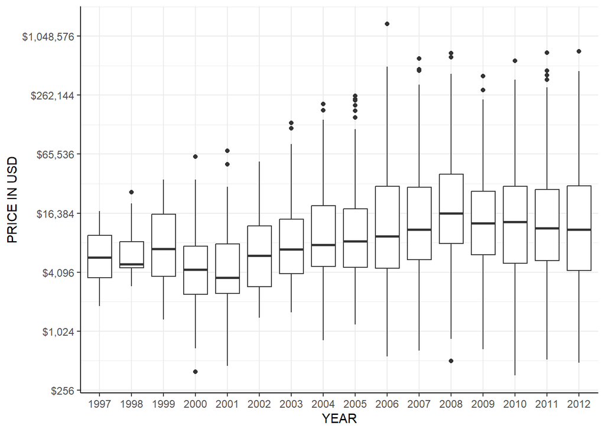

```r
library(ggplot2)
library(scales)
data$year <- as.factor(data$year)
ggplot(data, aes(x = price_usd, y = year)) +
  scale_x_continuous(trans = "log",
                     labels = dollar,
                     breaks = trans_breaks("log2", function(x) 2^x)
                     )+
  geom_boxplot()+
  coord_flip()+
  theme_bw()+
  xlab("PRICE IN USD")+
  ylab("YEAR")+
  theme(panel.border = element_blank(), axis.line = element_line())
```

## b. Does the distribution of genre of sales across years appear to change?

There are 5 genres in the data set, which are Photography, Print, Painting, Sculpture and Others. According to the result, painting accounted for a large amount of the sales from 1997-1999 and decreased rapidly after 2000, since 2000 the proportion of paintings kept fluctuating around 10%.

In replacement of painting, sculptures and photos becacme 2 dominant genres in terms of sales after 2000, where sculptures had a proportion of around 35% and photos had 40%. Print began to appear in the market from 2000, though Print only accounted for a small amount of the whole sales, the ratio was quite stable, and showed a tendency to grow.

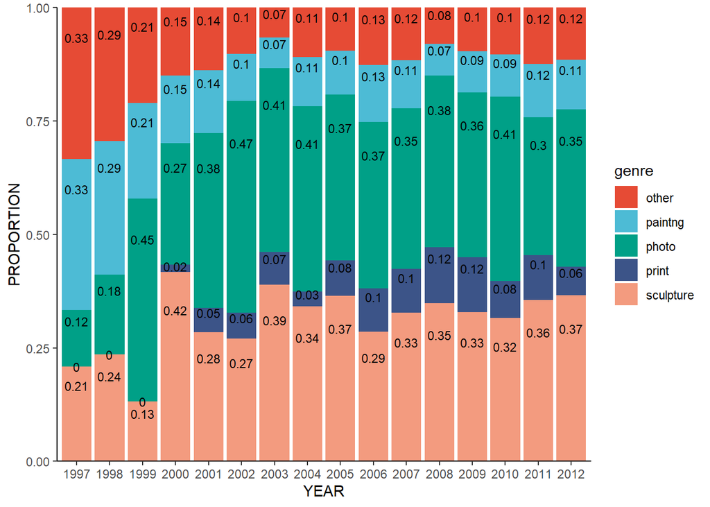

```r
library(ggsci)
data %>%
  group_by(year)%>%
  summarize(
      photo = sum(Genre___Photography),
      print = sum(Genre___Print),
      paintng = sum(Genre___Painting),
      sculpture = sum(Genre___Sculpture),
      other = sum(Genre___Others)
    )%>%
  tidyr:: pivot_longer(cols = !year)%>%
  mutate(genre = name,
         count = value
         )%>%
  select(year, genre, count) -> data_genre

data_genre %>% group_by(year)%>%
  mutate(ratio = round(count/sum(count), digit = 2)) -> data_genre

ggplot(data_genre, aes(x = year, y = count, fill = genre))+
  geom_bar(stat = "identity", position = "fill")+
  xlab("YEAR")+
  ylab("PROPORTION")+
  theme_classic()+
  geom_text(aes(label = ratio),
            position = position_fill(0.8), size = 3, vjust = 0.5)+
  scale_y_continuous(expand = c(0, 0))+
  scale_fill_npg()
```

## c. How does the genre affect the change in sales price over time?

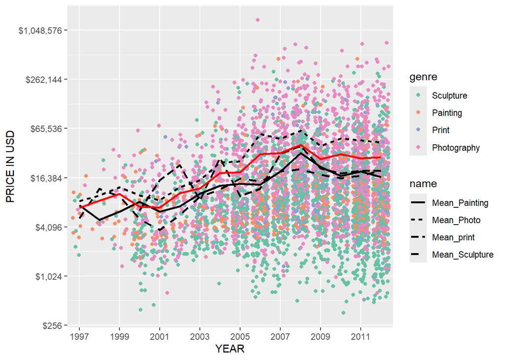

```r
data$genre <- 1*data$Genre___Sculpture + 2*data$Genre___Painting+
              3*data$Genre___Print+ 4*data$Genre___Photography

data <- data[data$genre!=0,]
data$genre <- factor(data$genre, labels = c("Sculpture", "Painting", "Print", "Photography"))
data %>%
  mutate( year = as.numeric(year))%>%
  group_by(year)%>%
  summarize(
    Yearly_mean = mean(price_usd),
    Mean_print = sum(price_usd*Genre___Print)/sum(Genre___Print),
    Mean_Sculpture = sum(price_usd*Genre___Sculpture)/sum(Genre___Sculpture),
    Mean_Painting = sum(price_usd*Genre___Painting)/sum(Genre___Painting),
    Mean_Photo = sum(price_usd*Genre___Photography)/sum(Genre___Photography)
  )%>% tidyr:: pivot_longer(cols = !year) -> yearly_data

ggplot(data, aes(x = year, y = price_usd, color = genre))+
  geom_jitter() +
  geom_line(aes(y = value, x = year, linetype = name),
            data = yearly_data[yearly_data$name!= "Yearly_mean",],
            color = "black",
            linewidth = 1)+
  geom_line(aes(y = value, x = year),
            data = yearly_data[yearly_data$name== "Yearly_mean",],
            color = "red",
            linewidth = 1)+
  scale_y_continuous(trans = "log",
                     labels = dollar,
                     breaks = trans_breaks("log2", function(x) 2^x)
                     )+
  scale_x_discrete(
                     breaks = seq(1997, 2012, 2)
                     )+
  scale_color_brewer(palette = "Set2")+
  ylab("PRICE IN USD")+
  xlab("YEAR")
```